# Project 2: Data Mining, Classification, Prediction

### Dimensionality Reduction with PCA

```r
eig2 <- heart_transplant %>% select(-X, -id, -survived, -prior,
    -transplant, -wait) %>% cor() %>% eigen()
eig2
```

```
## eigen() decomposition
## $values
## [1] 1.1191501 1.0656170 0.8152329
##
## $vectors
##            [,1]       [,2]       [,3]
## [1,] -0.1052791  0.8511647 -0.5142325
## [2,] -0.6676307 -0.4437397 -0.5977996
## [3,]  0.7370112 -0.2803815 -0.6149802
```

```r
eig2$vectors
```

```
##            [,1]       [,2]       [,3]
## [1,] -0.1052791  0.8511647 -0.5142325
## [2,] -0.6676307 -0.4437397 -0.5977996
## [3,]  0.7370112 -0.2803815 -0.6149802
```

```r
eig2$values
```

```
## [1] 1.1191501 1.0656170 0.8152329
```

```r
Y <- heart_transplant %>% select(3, 4, 6) %>% scale
head(round(Y, 3))
```

```
##      acceptyear    age survtime
## [1,]     -1.380  0.853   -0.722
## [2,]     -0.327 -0.167   -0.720
## [3,]      0.199  0.751   -0.720
## [4,]      0.726  0.751   -0.720
## [5,]     -1.380  0.955   -0.718
## [6,]     -0.327 -0.882   -0.718
```

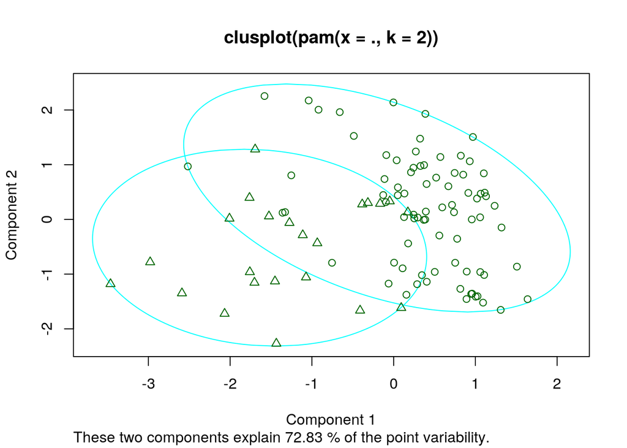

```r
plot(pam2, which = 1)
```

```r
PCAscores_heart <- Y %*% eig2$vectors
PCAscores_heart
```

```
##                [,1]          [,2]        [,3]
##   [1,] -0.956702200 -1.3503654890  0.64363067
##   [2,] -0.384390725 -0.0021768880  0.71104191
##   [3,] -1.053066881  0.0381896057 -0.10872413
##   [4,] -1.108475978  0.4861630936 -0.37936801
##   [5,] -1.021399331 -1.3969652256  0.57974363
##   [6,]  0.094316591  0.3141957390  1.13670020
##   [7,] -0.710641133  0.2639829005  0.19490701
##   [8,] -0.242943677  0.0864373382  0.82875886
##   [9,] -0.818015674  1.1586198059 -0.34925422
##  [10,] -0.811811498 -1.2630613333  0.75847415
##  [11,]  0.061287010 -1.1675588289  1.76128091
##  [12,] -0.944649414 -1.3549507360  0.63357353
##  [13,] -1.313577232 -0.1475543055 -0.36283556
##  [14,] -0.386108322  1.9196907443 -0.20142349
```

[output cut: 20 more lines]

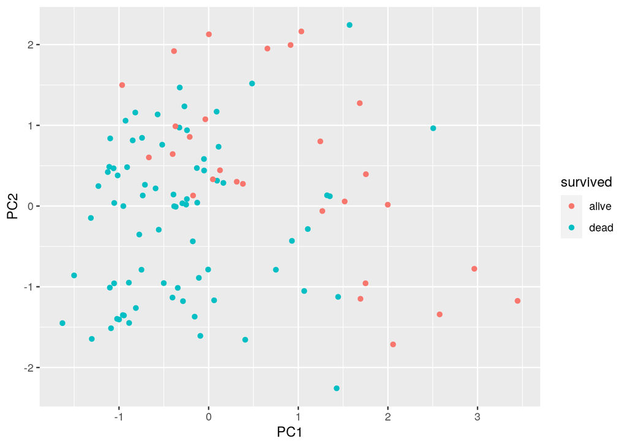

```r
heart_transplant %>% mutate(PC1 = PCAscores_heart[, 1], PC2 = PCAscores_heart[,
    2]) %>% ggplot(aes(PC1, PC2, color = survived)) + geom_point()
```

```r
heart_transplant_numeric <- heart_transplant %>% select(acceptyear,
    age, survtime)
pca1 <- princomp(heart_transplant_numeric, cor = T)
summary(pca1, loadings = T)
```

```
## Importance of components:
##                          Comp.1    Comp.2    Comp.3
## Standard deviation     1.057899 1.0322872 0.9029025
## Proportion of Variance 0.373050 0.3552057 0.2717443
## Cumulative Proportion  0.373050 0.7282557 1.0000000
##
## Loadings:
##            Comp.1 Comp.2 Comp.3
## acceptyear  0.105  0.851  0.514
## age         0.668 -0.444  0.598
## survtime   -0.737 -0.280  0.615
```

*The proportion of the total variance that comes from the first two principal components (PC1 and PC2) is 0.7283. Essentially, in terms of the original variables, PC1 compares the overall time. This means that the higher the PC1 value, the longer the time/year is for each variable with the exception of survtime which would be less. PC2 compares age and survtime to acceptyear higher PC2 means more time has passed for acceptyear, but less for age and survtime. PC3 compares all 3 together where a high PC3 value means a longer time has passed for all three variables.*